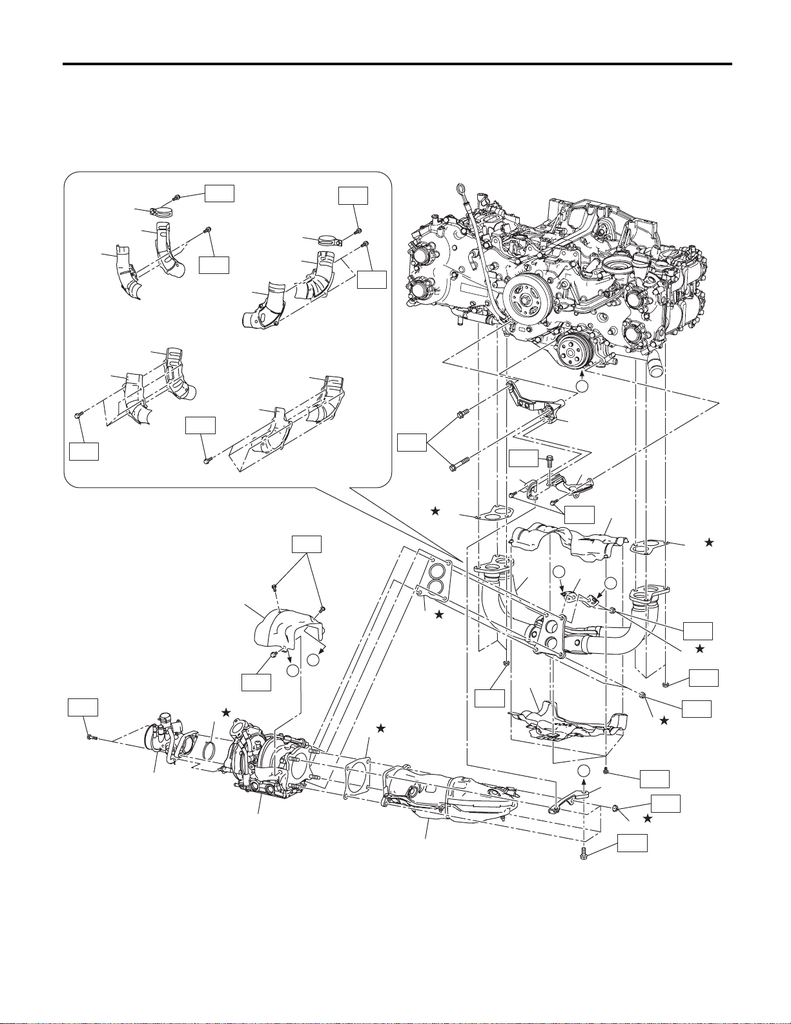

EX(w/o STI)-2

General Description

EXHAUST

1. General Description

A: COMPONENT

1. FRONT EXHAUST PIPE

C

A

A

B

C

(2)

(3)

(4)

(1)

(5)

(6)

(7)

(13)

(10)

(11)

(12)

(9)

(16)

(15)

(14)

(14)

T1

T6

T6

T6

T1

T6

T5

T1

T1

T3

T5

(8)

T6

EX-03086

(8)

(8)

T1

T1

T2

T2

(23)

(22)

(26)

(26)

(24)

(25)

T1

T1

(21)

(20)

(19)

(18)

B

T4

(17)

[figure not shown]

EX(w/o STI)-3

General Description

EXHAUST

(1) Intake duct No. 1 (13) Exhaust pipe cover C (25) Exhaust pipe cover K

(2) O-ring (14) Gasket (26) Front exhaust pipe band

(3) Turbocharger (15) Exhaust pipe stay B

(4) Exhaust pipe cover A (16) Water pump pulley cover Tightening torque: N·m (kgf-m, ft-lb)

(5) Gasket (17) Turbocharger stay B T1: 6.4 (0.7, 4.7)

(6) Center exhaust pipe (front) (18) Exhaust pipe cover D T2: 13 (1.3, 9.6)

(7) Turbocharger stay A (19) Exhaust pipe cover E T3: 19 (1.9, 14.0)

(8) Self-locking nut (20) Exhaust pipe cover F T4: 30 (3.1, 22.1)

(9) Exhaust pipe cover B (21) Exhaust pipe cover G T5: 33 (3.4, 24.3)

(10) Gasket (22) Exhaust pipe cover H T6: 42.5 (4.3, 31.3)

(11) Exhaust pipe stay A (23) Exhaust pipe cover I

(12) Front exhaust pipe (24) Exhaust pipe cover J

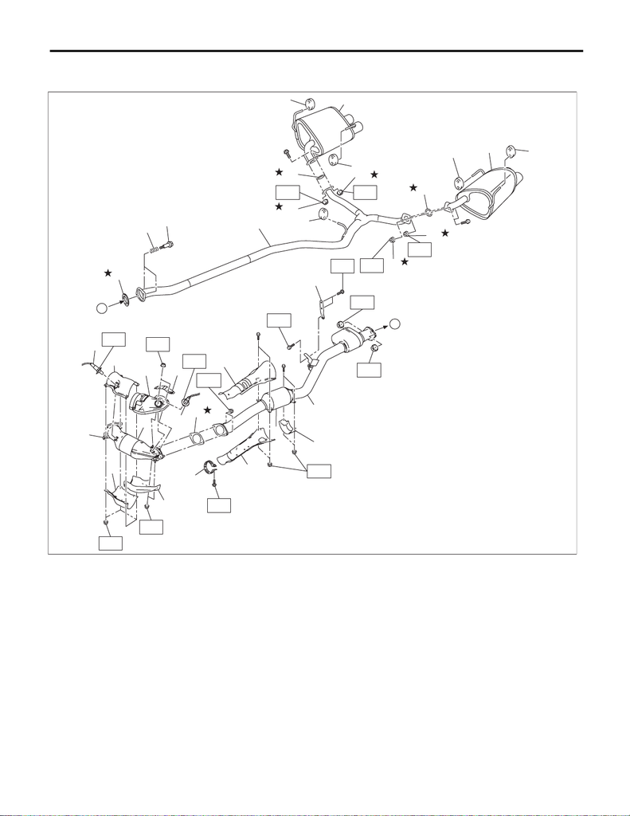

EX(w/o STI)-4

General Description

EXHAUST

2. CENTER AND REAR EXHAUST PIPE, AND MUFFLER

• CVT model

EX-03122

(17)

(22)

(25)

(22)

B

(13)

(7)

(16)

(5)

(9)

(14)

(8)

(12)

(3)

(11)

(2)

(6)

(4)

(10)

(1)

B

T5

T3

T3

T2

T2

T4

T1

T1

T1

(15)

T8

T9

T6

(18)

(19)

(20)

(21)

(22)

(23)

(23)

(23)

(23)

(24)

(24)

T7

T7

T7

T7

(22)

(26)

(22)

[figure not shown]

EX(w/o STI)-5

General Description

EXHAUST

(1) Center exhaust pipe (front) (14) Exhaust pipe cover G Tightening torque: N·m (kgf-m, ft-lb)

(2) Front catalytic converter (15) Center exhaust pipe band T1: 7.5 (0.8, 5.5)

(3) Rear catalytic converter (16) Exhaust pipe cover H T2: 13 (1.3, 9.6)

(4) Exhaust pipe cover A (17) Hanger bracket T3: 18 (1.8, 13.3)

(5) Exhaust pipe cover B (18) Gasket T4: 23 (2.3, 17.0)

(6) Exhaust pipe cover C (19) Spring T5: 35 (3.6, 25.8)

(7) Exhaust pipe cover D (20) Bolt T6: 42.5 (4.3, 31.3)

(8) Exhaust pipe cover E (21) Rear exhaust pipe T7: 48 (4.9, 35.4)

(9) Front oxygen (A/F) sensor (22) Cushion rubber T8: <Ref. to FU(w/o STI)-126,

INSTALLATION, Front Oxygen

(A/F) Sensor.>

(10) Rear oxygen sensor (23) Self-locking nut T9: <Ref. to FU(w/o STI)-129,

INSTALLATION, Rear Oxygen

Sensor.>

(11) Gasket (24) Gasket

(12) Center exhaust pipe (rear) (25) Muffler RH

(13) Exhaust pipe cover F (26) Muffler LH

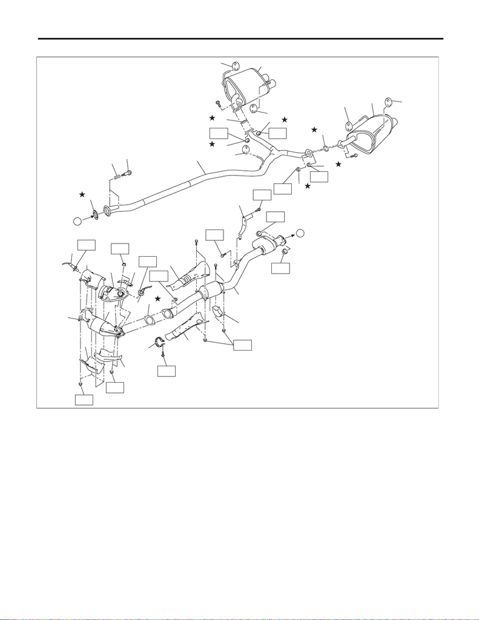

EX(w/o STI)-6

General Description

EXHAUST

•MT model

EX-03137

(22)

(25)

(22)

B

(13)

(7)

(16)

(5)

(9)

(14)

(8)

(12)

(3)

(11)

(2)

(6)

(4)

(10)

(1)

B

T5

T3

T3

T2

T2

(17)

T4

T1

T1

T1

(15)

T8

T9

T6

(18)

(19)

(20)

(21)

(22)

(23)

(23)

(23)

(23)

(24)

(24)

T7

T7

T7

T7

(22)

(26)

(22)

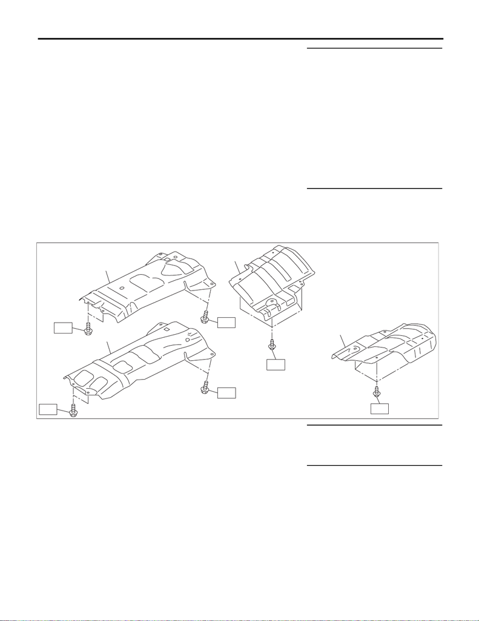

EX(w/o STI)-7

General Description

EXHAUST

3. HEAT SHIELD COVER

(1) Center exhaust pipe (front) (14) Exhaust pipe cover G Tightening torque: N·m (kgf-m, ft-lb)

(2) Front catalytic converter (15) Center exhaust pipe band T1: 7.5 (0.8, 5.5)

(3) Rear catalytic converter (16) Exhaust pipe cover H T2: 13 (1.3, 9.6)

(4) Exhaust pipe cover A (17) Hanger bracket T3: 18 (1.8, 13.3)

(5) Exhaust pipe cover B (18) Gasket T4: 23 (2.3, 17.0)

(6) Exhaust pipe cover C (19) Spring T5: 35 (3.6, 25.8)

(7) Exhaust pipe cover D (20) Bolt T6: 42.5 (4.3, 31.3)

(8) Exhaust pipe cover E (21) Rear exhaust pipe T7: 48 (4.9, 35.4)

(9) Front oxygen (A/F) sensor (22) Cushion rubber T8: <Ref. to FU(w/o STI)-126,

INSTALLATION, Front Oxygen

(A/F) Sensor.>

(10) Rear oxygen sensor (23) Self-locking nut T9: <Ref. to FU(w/o STI)-129,

INSTALLATION, Rear Oxygen

Sensor.>

(11) Gasket (24) Gasket

(12) Center exhaust pipe (rear) (25) Muffler RH

(13) Exhaust pipe cover F (26) Muffler LH

(1) Center exhaust cover (CVT

model)

(3) Rear exhaust cover RH Tightening torque: N·m (kgf-m, ft-lb)

(2) Center exhaust cover (MT model) (4) Rear exhaust cover LH T1: 10 (1.0, 7.4)

T2: 18 (1.8, 13.3)

EX-03123

T1

T1

(1)

T2

T2

(3)

(4)

T2

T2

(2)

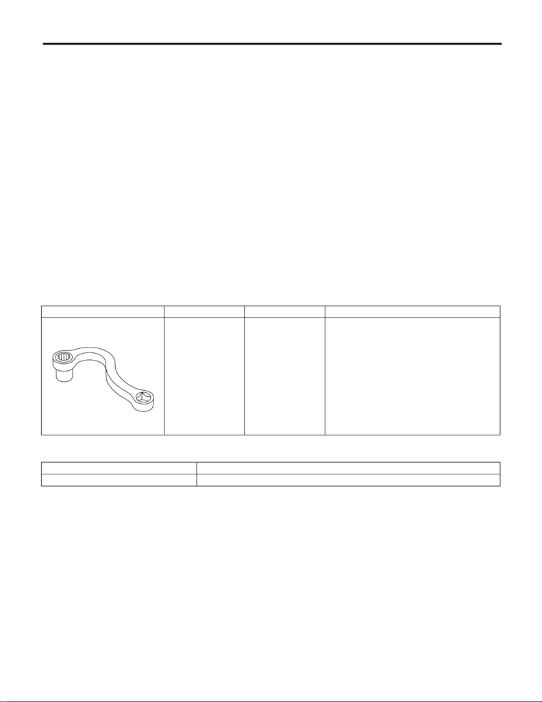

EX(w/o STI)-8

General Description

EXHAUST

B: CAUTION

• Prior to starting work, pay special attention to the following:

1. Always wear work clothes, a work cap, and protective shoes. Additionally, wear a helmet, protective

goggles, etc. if necessary.

2. Protect the vehicle using a seat cover, fender cover, etc.

3. Prepare the service tools, clean cloth, containers to catch grease and oil, etc.

• Vehicle components are extremely hot immediately after driving. Be wary of receiving burns from heated

parts.

• When performing a repair, identify the cause of trouble and avoid unnecessary removal, disassembly and

replacement.

• Before disconnecting connectors of sensors or units, be sure to disconnect the ground cable from battery.

• Always use the jack-up point when the shop jacks or rigid racks are used to support the vehicle.

• Remove contamination including dirt and corrosion before removal, installation, disassembly or assembly.

• Keep the removed parts in order and protect them from dust and dirt.

• All removed parts, if to be reused, should be reinstalled in the original positions with attention to the correct

directions, etc.

• Bolts, nuts and washers should be replaced with new parts as required.

• Be sure to tighten the fasteners including bolts and nuts to the specified torque.

• If any grease adheres to the exhaust pipe, wipe it off. Otherwise a fire may happen.

C: PREPARATION TOOL

1. SPECIAL TOOL

2. GENERAL TOOL

ILLUSTRATION TOOL NUMBER DESCRIPTION REMARKS

18283AA010 WRENCH

ADAPTER

Used for removing and installing center exhaust

pipe (front).

TOOL NAME REMARKS

TORX

®

socket E10 Used for removing and installing center exhaust pipe (front).

ST18283AA010